# HW5

Sila Aydin

7.01.2019

## Data

In this assignment there is one dataset called Musk, which contains 92 bags of a total of 476 instances (molecules). Bags are classified as musk and non-musk. The goal is to represent the instances in a bag as one instance and achieve a total of 92 instances then classify these instances using lasso logistic regression.

To do this first all 476 instances need to be clustered and then each bag is represented as the average of its instance distances to cluster centers.

Two clustering algorithms, k-medoids and hierarchical clustering, and two distance measures, manhattan and euclidean, are considered. To apply clustering first the data is scaled. The number of clusters are chosen by looking at 2 measures: silhouete and within-cluster sum of squares. fviz_nbclust() function of “factoextra” package is convenient to visualize and choose number of clusters. For k-medoids approach 2 clusters are chosen and for hierarchical clustering 3 clusters are chosen.

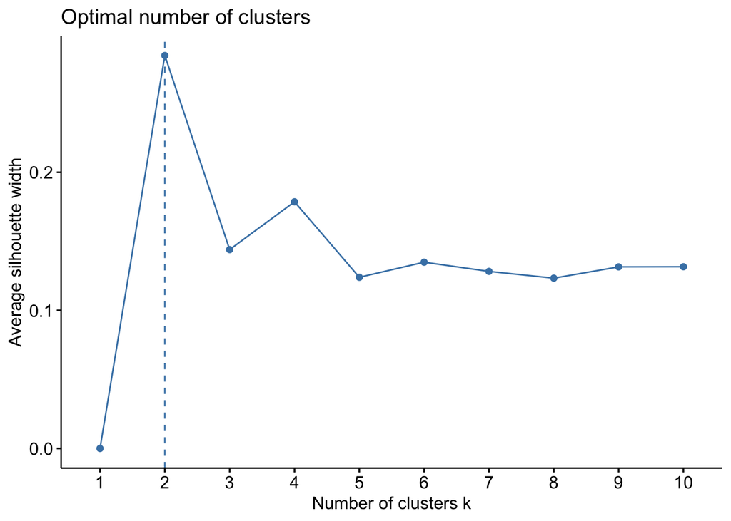

```r
# for kmedoids choose 2 clusters
fviz_nbclust(musktoclus, pam, method = "silhouette")
```

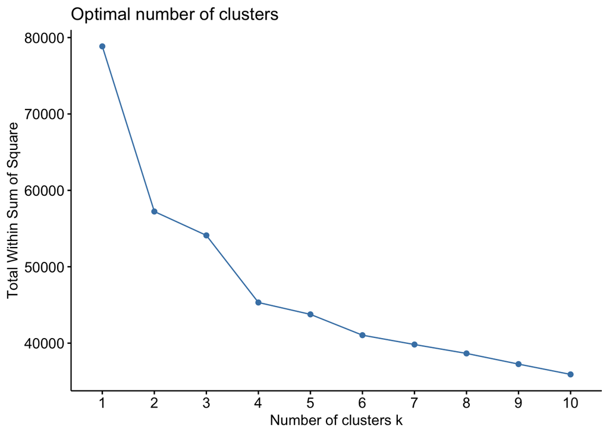

```r
fviz_nbclust(musktoclus, pam, method = "wss")
```

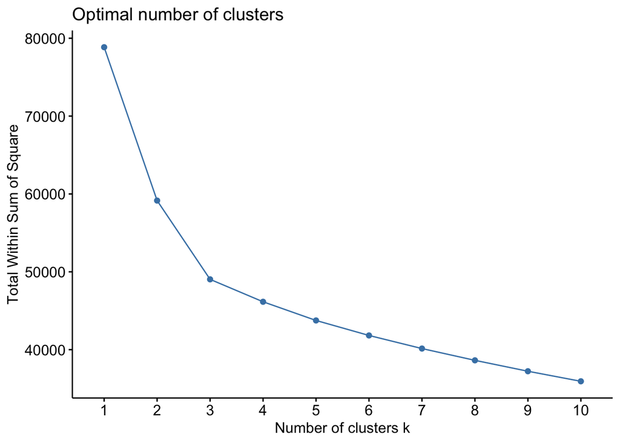

```r
# for hierarchichal choose 3 clusters
fviz_nbclust(musktoclus, hcut, method = "wss")
```

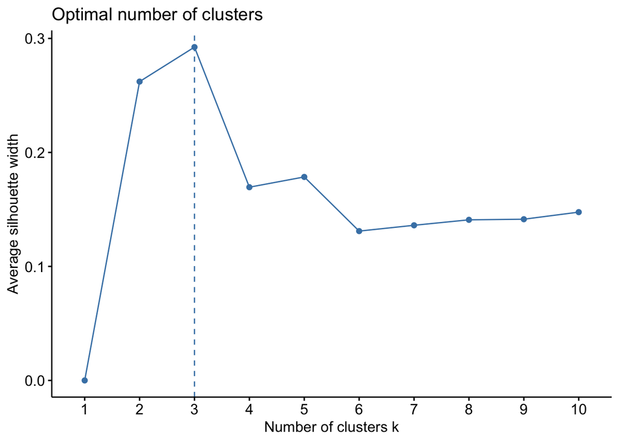

```r
fviz_nbclust(musktoclus, hcut, method = "silhouette")
```

With the chosen k’s the clustering algorithms are applied using the 2 distance measures. Below are the plot of the clusters made with pam():

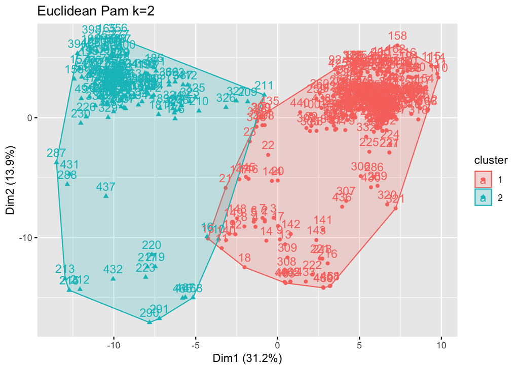

```r
fviz_cluster(med_euc, data = musktoclus, main = "Euclidean Pam k=2")
```

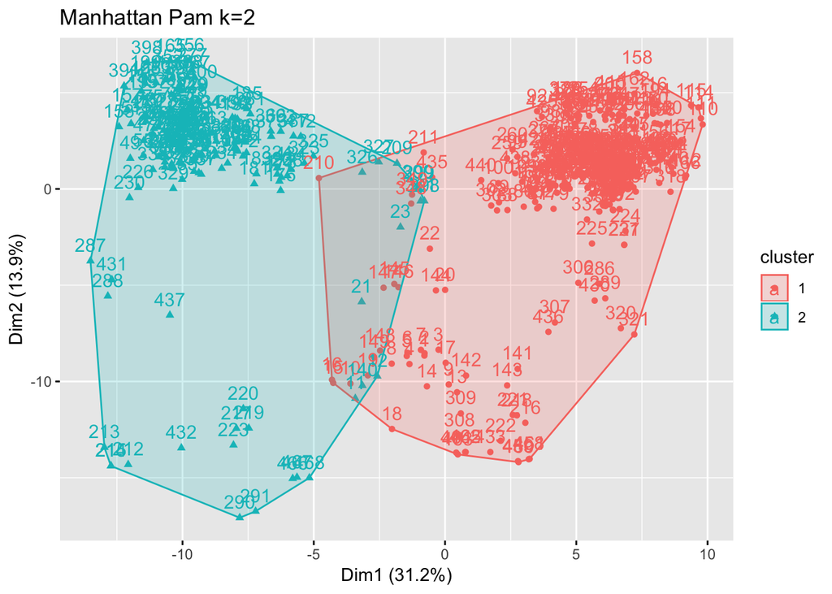

```r
fviz_cluster(med_man, data = musktoclus, main = "Manhattan Pam k=2")
```

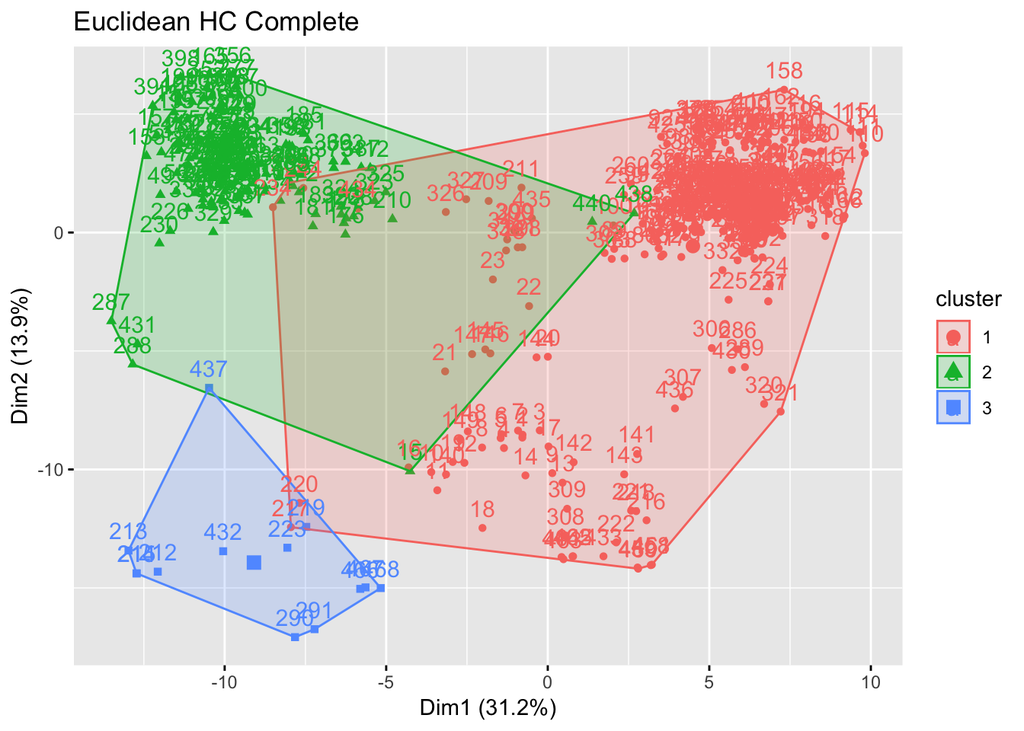

```r
fviz_cluster(list(data = musktoclus , cluster = hc_euc_cut), main = "Euclidean HC Complete")
```

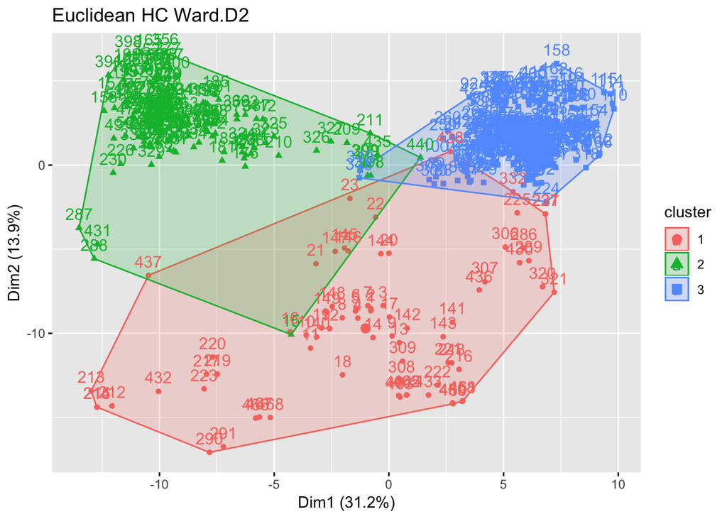

```r
fviz_cluster(list(data = musktoclus , cluster = hc_euc_cut_w), main = "Euclidean HC Ward.D2")
```

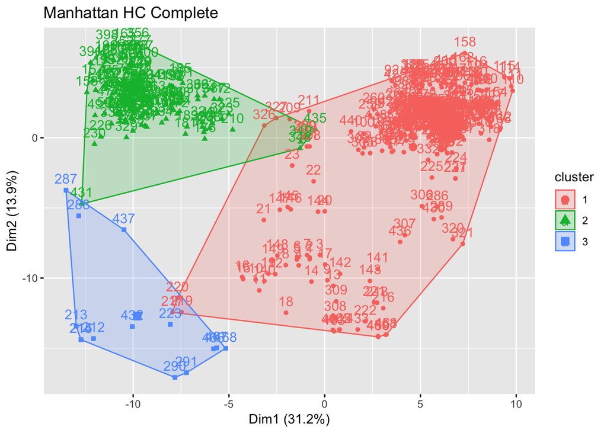

```r
fviz_cluster(list(data = musktoclus , cluster = hc_man_cut), main = "Manhattan HC Complete")
```

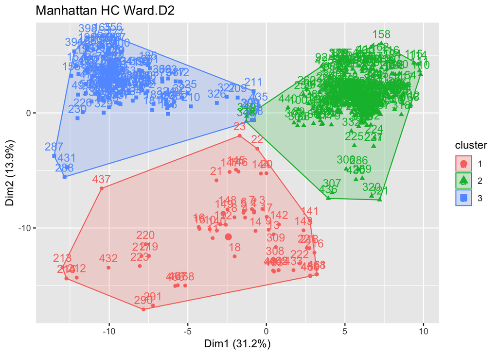

```r
fviz_cluster(list(data = musktoclus , cluster = hc_man_cut_w), main = "Manhattan HC Ward.D2")
```

```r
#from the plots ward.D2 method produces a better clustering for manhattan distance so ward.D2 will be used for both
```

Then, the distance of the instances in the bag to the cluster centers are calculated and averages are taken to represent each bag. For k-medoids bags are represented with 2 features and for hierarchical clustering with 3 features.

A function was developed that performs 10-fold cross-validation with 2 replaications and returns the highest area under curve value. Hierarchical clustering applied with Manhattan distance and with 3 clusters has the highest AUC value, 0.795, and is chosen as the best method to use when representing the bags with one feature vector.

```r
hc_euc_auc = clust_lasso(ma_hc_euc)
hc_man_auc = clust_lasso(ma_hc_man)
pam_euc_auc = clust_lasso(ma_pam_euc)
pam_man_auc = clust_lasso(ma_pam_man)

hc_euc_auc #euclidean hierarchical clustering with k=3
```

```
## [[1]]
## [1] 0.66375
```

```r
hc_man_auc #mnahattan hierarchical clustering with k=3
```

```
## [[1]]
## [1] 0.795
```

```r
pam_euc_auc #euclidean k-medoids clustering with k=2
```

```
## [[1]]
## [1] 0.66375
```

```r
pam_man_auc #manhattan k-medoids clustering with k=2
```

```
## [[1]]
## [1] 0.67375
```

## Appendix

### Main

```r
library(cluster)
library(TunePareto)
library(glmnet)
library(pROC)
require(data.table)
require(factoextra)

source('lasso_clust.r')
musk = as.data.table(read.csv("/Users/silaaydin/Desktop/fall18/582/hw/hw5/Musk1.csv", header = F))
# there are 92 molecules/bags. Instances in bags are different conformations of the same molecules
# cluster all instances. for one bag: look at the distances of the instances in that bag and take the average
# of these distances and use this as the feature vector of the bag
musktoclus = musk[,-c(1,2)]
setnames(musk,"V1", "bag_class")
setnames(musk,"V2", "bag_id")
musktoclus = scale(musktoclus)

# for kmedoids choose 2 clusters
fviz_nbclust(musktoclus, pam, method = "silhouette")
fviz_nbclust(musktoclus, pam, method = "wss") #choose 2 clusters
# for hierarchichal choose 3 clusters
fviz_nbclust(musktoclus, hcut, method = "wss") #choose 3 clusters
fviz_nbclust(musktoclus, hcut, method = "silhouette")

set.seed(20)
med_euc<-pam(musktoclus, 2, metric = c("euclidean"))       ##pam with different distance measures
med_man<-pam(musktoclus, 2, metric = c("manhattan"))

fviz_cluster(med_euc, data = musktoclus, main = "Euclidean Pam")    ##plots
fviz_cluster(med_man, data = musktoclus, main = "Manhattan Pam")

hc_euc<-hclust(dist(musktoclus, method = "euclidean"), method="complete")
hc_euc_w<-hclust(dist(musktoclus, method = "euclidean"), method="ward.D2")
hc_man<-hclust(dist(musktoclus, method = "manhattan"), method="complete")
hc_man_w<-hclust(dist(musktoclus, method = "manhattan"), method="ward.D2")

plot(hc_euc)
plot(hc_man)

hc_euc_cut <- cutree(hc_euc, k = 3)
hc_euc_cut_w <- cutree(hc_euc_w, k = 3)
hc_man_cut <- cutree(hc_man, k = 3)
hc_man_cut_w <- cutree(hc_man_w, k = 3)

fviz_cluster(list(data = musktoclus , cluster = hc_euc_cut), main = "Euclidean HC")
fviz_cluster(list(data = musktoclus , cluster = hc_euc_cut_w), main = "Euclidean HC Ward.D2")
fviz_cluster(list(data = musktoclus , cluster = hc_man_cut), main = "Manhattan HC")
fviz_cluster(list(data = musktoclus , cluster = hc_man_cut_w), main = "Manhattan HC Ward.D2")
#from the plots war.D2 method produces a better clustering for manhattan distance so ward.D2 will be used for both

cent_hc_euc = apply (musktoclus, 2, function (x) tapply (x,hc_euc_cut_w, mean))
cent_hc_man = apply (musktoclus, 2, function (x) tapply (x, hc_man_cut_w, mean))
dist_hc_euc = musk[,1:2]
dist_hc_man = musk[,1:2]
dist_pam_euc = musk[,1:2]
dist_pam_man = musk[,1:2]

for( i in 1:3){
dist_hc_euc = cbind(dist_hc_euc, apply(musktoclus, 1, function(x) {sqrt(sum(x-cent_hc_euc[i,])^2)}))
dist_hc_man = cbind(dist_hc_man, apply(musktoclus, 1, function(x) {sum(abs(x-cent_hc_man[i,]))}))
}

for(i in 1:2){
  dist_pam_euc = cbind(dist_pam_euc, apply(musktoclus, 1, function(x) {sqrt(sum(x-med_euc$medoids[i,])^2)}))
  dist_pam_man = cbind(dist_pam_man, apply(musktoclus, 1, function(x) {sum(abs(x-med_man$medoids[i,]))}))
}

colnames(dist_hc_euc) = c("bag_class", "bag_id","C1", "C2", "C3")
colnames(dist_hc_man) = c("bag_class", "bag_id","C1", "C2", "C3")
colnames(dist_pam_euc) = c("bag_class", "bag_id","C1", "C2")
colnames(dist_pam_man) = c("bag_class", "bag_id","C1", "C2")


dist_hc_euc[, avg1 := mean(C1), by = .(bag_id)]
dist_hc_euc[, avg2 := mean(C2), by = .(bag_id)]
dist_hc_euc[, avg3 := mean(C3), by = .(bag_id)]
ma_hc_euc = unique(dist_hc_euc[, list(bag_class, bag_id, avg1, avg2, avg3)])
dist_hc_man[, avg1 := mean(C1), by = .(bag_id)]
dist_hc_man[, avg2 := mean(C2), by = .(bag_id)]
dist_hc_man[, avg3 := mean(C3), by = .(bag_id)]
ma_hc_man = unique(dist_hc_man[, list(bag_class, bag_id, avg1, avg2, avg3)])
dist_pam_euc[, avg1 := mean(C1), by = .(bag_id)]
dist_pam_euc[, avg2 := mean(C2), by = .(bag_id)]
ma_pam_euc = unique(dist_pam_euc[, list(bag_class, bag_id, avg1, avg2)])
dist_pam_man[, avg1 := mean(C1), by = .(bag_id)]
dist_pam_man[, avg2 := mean(C2), by = .(bag_id)]
ma_pam_man = unique(dist_pam_man[, list(bag_class, bag_id, avg1, avg2)])

hc_euc_auc = clust_lasso(ma_hc_euc)
hc_man_auc = clust_lasso(ma_hc_man)
pam_euc_auc = clust_lasso(ma_pam_euc)
pam_man_auc = clust_lasso(ma_pam_man)

hc_euc_auc
hc_man_auc
pam_euc_auc
pam_man_auc
```

### Lasso Logistic Regression Function

```r
clust_lasso <- function(train){
      set.seed(15)
      alpha=1
      nofReplications=2
      nFolds=10
      nlambda=70
      # glmnet works with complete data
      train=train[complete.cases(train)]
      train_class=as.factor(train$bag_class)
      train = train[, -c(1:2)]
      cvindices=generateCVRuns(train_class,nofReplications,nFolds,stratified=TRUE)
      glmnet_alldata = glmnet(as.matrix(train), as.factor(train_class), family="binomial", alpha = alpha, nlambda=nlambda)
      lambda_sequence = glmnet_alldata$lambda
      cvresult=vector('list',nofReplications*nFolds)
      iter=1
        for(i in 1:nofReplications) {
            thisReplication=cvindices[[i]]
            for(j in 1:nFolds){
                testindices=thisReplication[[j]]

                cvtrain=train[-testindices]
                cvtrainclass=train_class[-testindices]
                cvtest=train[testindices]
                cvtestclass=train_class[testindices]

                inner_cv_glmnet_fit = glmnet(as.matrix(cvtrain),as.factor(cvtrainclass),family="binomial", alpha = alpha,lambda=lambda_sequence)
                valid_pred = predict(inner_cv_glmnet_fit, as.matrix(cvtest), s = lambda_sequence, type = "class")
                valid_pred=t(as.matrix(valid_pred))
                #check order of predictions
                foldresult=rbindlist(lapply(c(1:length(lambda_sequence)),function(x) { data.table(repl=i,fold=j,lambda=lambda_sequence[x],
                                                                                                  pred = valid_pred[x,], bag_class=cvtestclass, auc = auc(roc(cvtestclass, as.numeric(valid_pred[x,]))))}))
                cvresult[[iter]]=foldresult
                iter=iter+1
            }
        }
        cvresult=rbindlist(cvresult)
        final=unique(cvresult[,list(auc),list(repl,fold,lambda)])
        final[, mean(auc), by = list(lambda)]
        maxauc = max(final[, mean(auc), by = .(lambda)]$V1)
    return(list(maxauc))
}
```